(linthsa)=

# Linth survey area

*Map of survey locations March 2020 - May 2021*

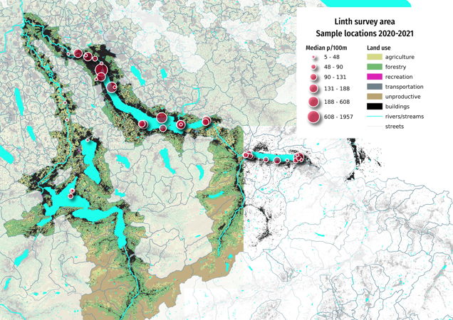

## Sample locations and land use characteristics

For the period between 2020-03 and 2021-05, a total of 9,412 objects were removed and identified over the course of 112 surveys. The Linth survey area results include 40 different locations, 17 different municipalities with a combined population of approximately 612,111.

*Linth survey area lakes:*

> Quatre Cantons, Walensee, Zugersee, Zurichsee

*Linth survey area rivers:*

> Dorfbach, Escherkanal, Jona, Limmat, Linthkanal, Reuss, Seez, Sihl

*Linth survey area municipalities:*

> Dietikon, Freienbach, Glarus Nord, Hünenberg, Küsnacht (ZH), Merenschwand, Quarten, Rapperswil-Jona, Richterswil, Schmerikon, Stäfa, Unterengstringen, Walenstadt, Weesen, Weggis, Zug, Zürich

### Land use profile of the surveys

The land use is reported as the percent of total area attributed to each land use category within a 1500m radius of the survey location.

Streets are reported as the total number of kilometers of streets within the 1500m radius. Intersects is also an ordinal ranking of the number of rivers/canals that intersect a lake within 1500m of the survey location.

The ratio of the number of samples under varying land use profiles gives an indication of the environmental and economic conditions of the survey sites.

For more information *Land use profile*

**Below:** Distribution of land use characteristics.

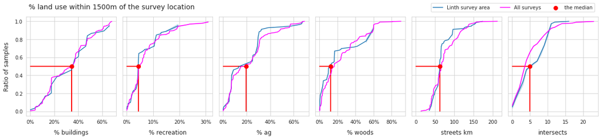

### Cumulative totals by water feature

**Below:** The cumulative weights and measures for the Linth survey area and water bodies.

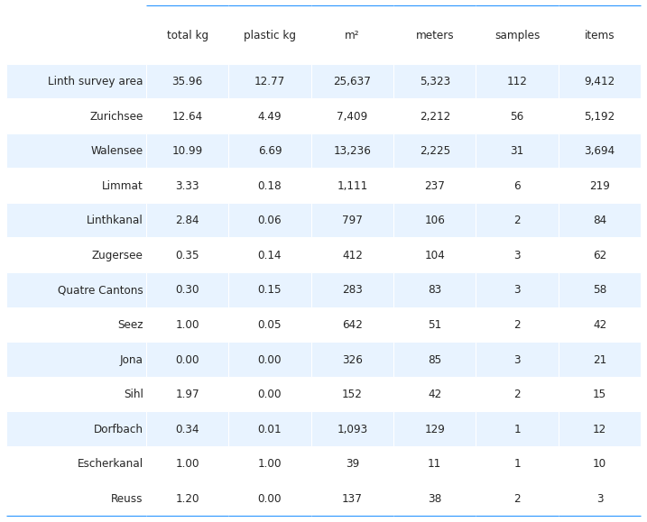

### Distribution of survey results

**Left:** Linth survey area, 2020-03 through 2021-05, n=112. Values greater than 1594.8 not shown. **Right:** Linth survey area empirical cumulative distribution of survey results.

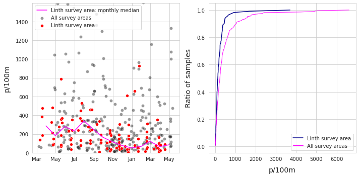

### Summary data and material types

**Left:** Linth survey area summary of survey totals. **Right:** Linth survey area material type and percent of total.

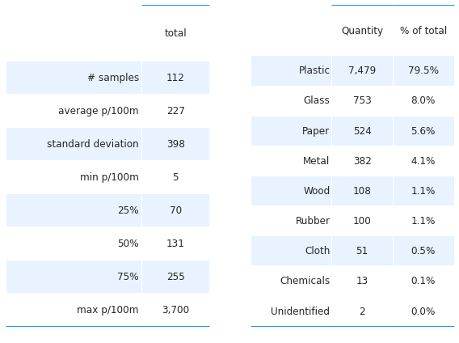

## The most common objects

The most common objects are the **ten most abundant by quantity AND/OR objects identified in at least 50% of all surveys.**

Note : p/100m = median survey value.

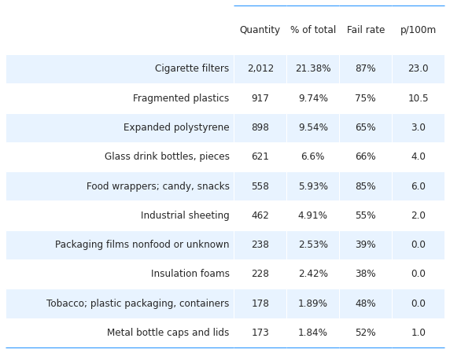

### Most common objects by water feature

**Below:** Linth survey area most common objects: median p/100m

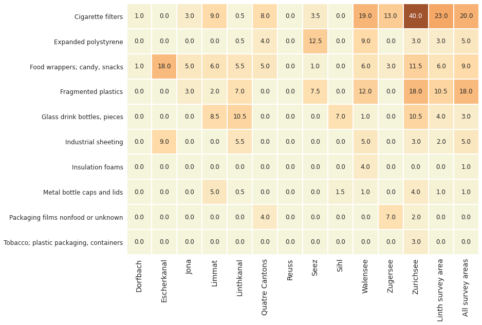

### Most common objects monthly average

*Linth survey area, monthly average survey result p/100m, with detail of the most common objects.*

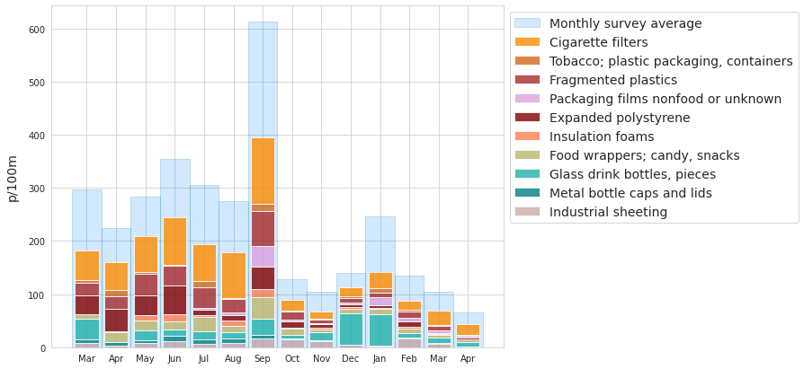

## Survey results and land use

The land use mix is a unique representation of the type and amplitude of the economic activity and the environmental conditions around the survey location. The key indicators from the survey results are compared against the land use rates for a radius of 1500m from the survey location.

An association is a relationship between the survey results and the land use profile that is unlikely due to chance. The magnitude of the relationship is neither defined nor linear.

Ranked correlation is a non-parametric test to determine if there is a statistically significant relationship between land use and the objects identified in a litter survey.

The method used is the Spearman’s rho or Spearmans ranked correlation coefficient. The test results are evaluated at p<0.05 for all valid lake samples in the survey area.

1. Red/rose is a positive association
2. Yellow is a negative association
3. White means that p>0.05, there is no statistical basis to assume an association

*There are less than 100 samples, proceed with caution. Beach litter surveys have alot of variance*

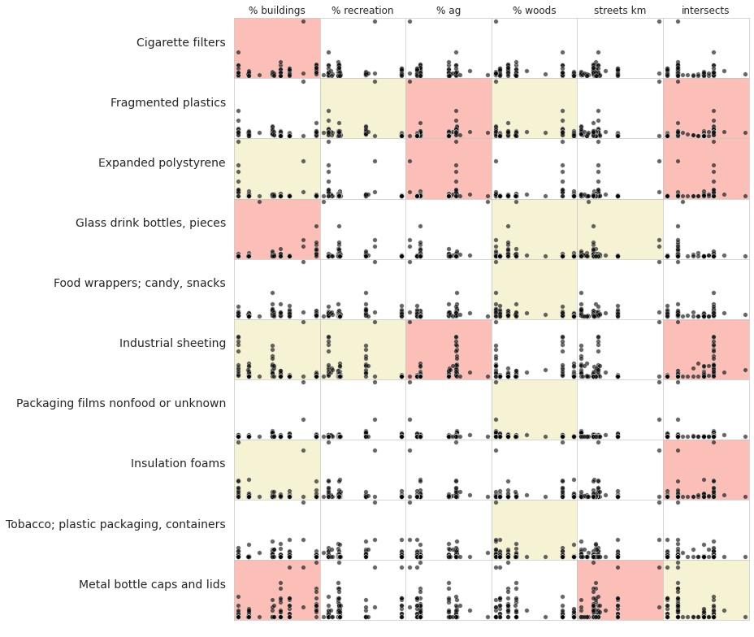

*Key: if p>0.05 = white, if p < 0.05 and $\rho$ > 0 = red, if p < 0.05 and $\rho$ < 0 = yellow*

## Utility of the objects found

The utility type is based on the utilization of the object prior to it being discarded or object description if the original use is undetermined. Identified objects are classified into one of 260 predefined categories. The categories are grouped according to utilization or item description.

- **wastewater**: items released from water treatment plants includes items likely toilet flushed
- **micro plastics (< 5mm)**: fragmented plastics and pre-production plastic resins
- **infrastructure**: items related to construction and maintenance of buildings, roads and water/power supplies
- **food and drink**: all materials related to consuming food and drink
- **agriculture**: primarily industrial sheeting i.e., mulch and row covers, greenhouses, soil fumigation, bale wraps. Includes hard plastics for agricultural fencing, flowerpots etc.
- **tobacco**: primarily cigarette filters, includes all smoking related material
- **recreation**: objects related to sports and leisure i.e., fishing, hunting, hiking etc.
- **packaging non food and drink**: packaging material not identified as food, drink nor tobacco related
- **plastic fragments**: plastic pieces of undetermined origin or use
- **personal items**: accessories, hygiene and clothing related

See the annex for the complete list of objects identified, includes descriptions and group classification. The section Code groups describes each code group in detail and provides a comprehensive list of all objects in a group.

**Below:** Linth survey area utility of objects found % of total by water feature. Fragmented objects with no clear identification remain classified by size.

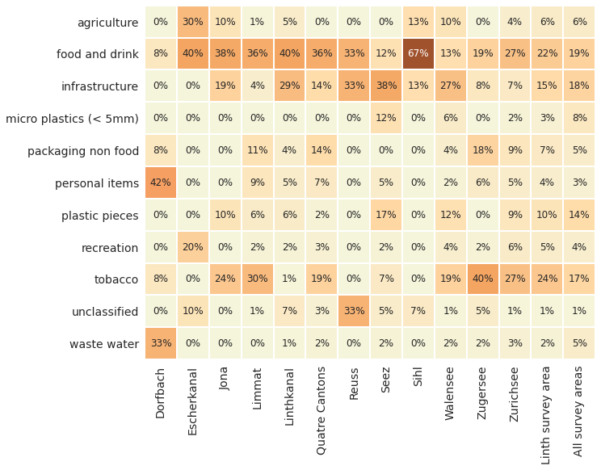

**Below:** Linth survey area utility of objects found median p/100m. Fragmented objects with no clear identification remain classified by size.

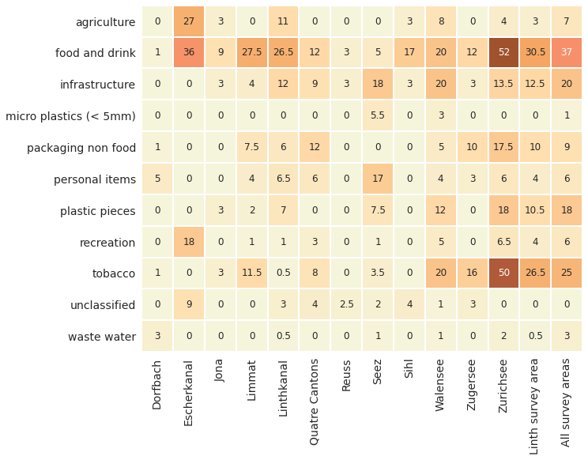

## Rivers

**Left:** Linth survey area rivers, 2020-03 through 2021-05, n=19. Values greater than 1594.8 not shown. **Right:** Summary data.

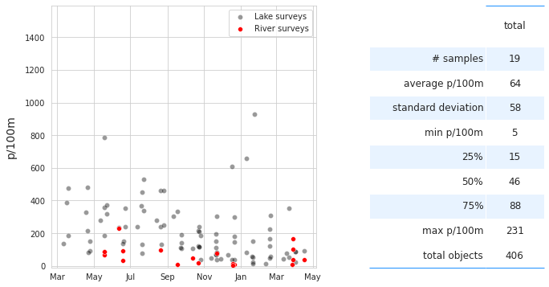

### Rivers most common objects

**Below:** Linth survey area rivers, most common objects p/100m: median survey value

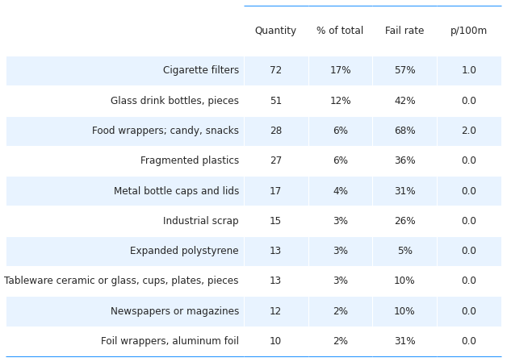

## Annex

### Fragmented foams and plastics by size

The table below contains the “Gfoam” and “Gfrags” components grouped for analysis. Objects labeled expanded foams are grouped as Gfoam and includes all expanded polystyrene foamed plastics > 0.5 cm. Plastic pieces and objects made of combined plastic and foamed plastic materials > 0.5 cm. are grouped for analysis as Gfrags.

**Below:** Linth survey area fragmented foams and plastics by size group.

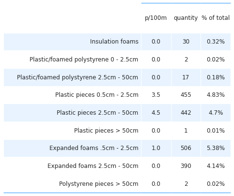

### Organizations

1. Association pour la Sauvegarde du Léman
2. Precious Plastic Léman
3. Hackuarium
4. Solid waste engineering (EPFL)
5. Geneva International School
6. Hammerdirt

**The survey locations**

| location | latitude | longitude | city |
| --- | --- | --- | --- |
| limmat_dietikon_keiserp | 47.407989 | 8.409540 | Dietikon |
| zugerseecholler_cham_blarerm | 47.178216 | 8.480013 | Zug |
| vierwaldstattersee_weggis_schoberls_1 | 47.044532 | 8.418569 | Weggis |
| vierwaldstattersee_weggis_schoberls_2 | 47.043953 | 8.417308 | Weggis |
| vierwaldstattersee_weggis_schoberls_3 | 47.029957 | 8.410801 | Weggis |
| limmat_unterengstringen_oggierbuhrer | 47.409400 | 8.446933 | Unterengstringen |
| limmat_zuerich_wagnerc | 47.403496 | 8.477770 | Zürich |
| limmat_zurich_mortensena_meiera | 47.400252 | 8.485411 | Zürich |
| sihl_zuerich_eggerskoehlingera | 47.381898 | 8.538328 | Zürich |
| gasi-strand | 47.128442 | 9.110831 | Weesen |
| rastplatz-stampf | 47.215177 | 8.844286 | Rapperswil-Jona |
| zuerichsee_richterswil_benkoem_2 | 47.217646 | 8.698713 | Richterswil |
| walensee_walenstadt_wysse | 47.121828 | 9.299552 | Walenstadt |
| pfafikon-bad | 47.206766 | 8.774182 | Freienbach |
| zurichsee_kusnachterhorn_thirkell-whitej | 47.317685 | 8.576860 | Küsnacht (ZH) |
| zurichsee_wollishofen_langendorfm | 47.345890 | 8.536155 | Zürich |
| untertenzen | 47.115260 | 9.254780 | Quarten |
| zurcher-strand | 47.364200 | 8.537420 | Zürich |
| jona-river-rastplatz | 47.216100 | 8.844430 | Rapperswil-Jona |
| reuss_hunenberg_eberhardy | 47.232976 | 8.401012 | Hünenberg |
| reuss_ottenbach_schoenenbergerl | 47.278354 | 8.394224 | Merenschwand |
| zuerichsee_staefa_hennm | 47.234643 | 8.769881 | Stäfa |
| linthdammweg | 47.131790 | 9.091910 | Weesen |
| mols-rocks | 47.114343 | 9.288174 | Quarten |
| seeflechsen | 47.130223 | 9.103400 | Glarus Nord |
| seemuhlestrasse-strand | 47.128640 | 9.295100 | Walenstadt |
| muhlehorn-dorf | 47.118448 | 9.172124 | Glarus Nord |
| zuerichsee_waedenswil_colomboc_1 | 47.219547 | 8.691961 | Richterswil |
| murg-bad | 47.115307 | 9.215691 | Quarten |
| schmerikon-bahnhof-strand | 47.224780 | 8.944180 | Schmerikon |
| aabach | 47.220989 | 8.940365 | Schmerikon |
| sihl_zuerich_eichenbergerd | 47.339588 | 8.516697 | Zürich |
| kusnachter-dorfbach-tobelweg-1-4 | 47.317770 | 8.588258 | Küsnacht (ZH) |
| flibach-river-right-bank | 47.133742 | 9.105461 | Weesen |
| linth_route9brucke | 47.125730 | 9.117340 | Glarus Nord |
| seez_spennwiesenbrucke | 47.114948 | 9.310123 | Walenstadt |
| linth_mollis | 47.131370 | 9.094768 | Glarus Nord |
| seez | 47.119830 | 9.300251 | Walenstadt |
| limmat_zuerich_suterdglauserp | 47.394539 | 8.513443 | Zürich |
| strandbeiz | 47.215862 | 8.843098 | Rapperswil-Jona |

### Inventory of items

| code | item | groupname | quantity | % of total | fail rate |
| --- | --- | --- | --- | --- | --- |
| G27 | Cigarette filters | tobacco | 2012 | 21.38 | 87 |
| Gfrags | Fragmented plastics | plastic pieces | 917 | 9.74 | 75 |
| Gfoam | Expanded polystyrene | infrastructure | 898 | 9.54 | 65 |
| G200 | Glass drink bottles, pieces | food and drink | 621 | 6.60 | 66 |
| G30 | Food wrappers; candy, snacks | food and drink | 558 | 5.93 | 85 |
| G67 | Industrial sheeting | agriculture | 462 | 4.91 | 55 |
| G941 | Packaging films nonfood or unknown | packaging non food | 238 | 2.53 | 39 |
| G74 | Insulation foams | infrastructure | 228 | 2.42 | 38 |
| G25 | Tobacco; plastic packaging, containers | tobacco | 178 | 1.89 | 48 |
| G178 | Metal bottle caps and lids | food and drink | 173 | 1.84 | 52 |
| G156 | Paper fragments | packaging non food | 151 | 1.60 | 41 |
| G117 | Expanded foams < 5mm | micro plastics (< 5mm) | 134 | 1.42 | 18 |
| G89 | Plastic construction waste | infrastructure | 117 | 1.24 | 41 |
| G177 | Foil wrappers, aluminum foil | food and drink | 112 | 1.19 | 39 |
| G923 | Tissue, toilet paper, napkins, paper towels | personal items | 106 | 1.13 | 28 |
| G73 | Foamed items & pieces (non packaging/insulatio... | recreation | 95 | 1.01 | 11 |
| G96 | Sanitary-pads/tampons, applicators | waste water | 93 | 0.99 | 13 |
| G24 | Plastic lid rings | food and drink | 85 | 0.90 | 38 |
| G21 | Drink lids | food and drink | 80 | 0.85 | 34 |
| G112 | Industrial pellets (nurdles) | micro plastics (< 5mm) | 72 | 0.76 | 19 |
| G211 | Swabs, bandaging, medical | personal items | 71 | 0.75 | 25 |
| G155 | Fireworks paper tubes and fragments | recreation | 70 | 0.74 | 9 |
| G95 | Cotton bud/swab sticks | waste water | 70 | 0.74 | 32 |
| G31 | Lollypop sticks | food and drink | 63 | 0.67 | 30 |
| G23 | Lids unidentified | packaging non food | 61 | 0.65 | 29 |
| G904 | Plastic fireworks | recreation | 59 | 0.63 | 24 |
| G153 | Cups, food containers, wrappers (paper) | food and drink | 58 | 0.62 | 23 |
| G106 | Plastic fragments angular <5mm | micro plastics (< 5mm) | 58 | 0.62 | 13 |
| G10 | Food containers single use foamed or plastic | food and drink | 56 | 0.59 | 21 |
| G922 | Labels, bar codes | packaging non food | 54 | 0.57 | 22 |

[output cut: 138 more lines]